# Evaluation of high-precision analytical techniques for measuring atmospheric nitrous oxide (N<sub>2</sub>O)

Elise-Andree Guerette

CSIRO Climate Science Centre - Atmospheric Composition & Chemistry - Major Greenhouse Gases

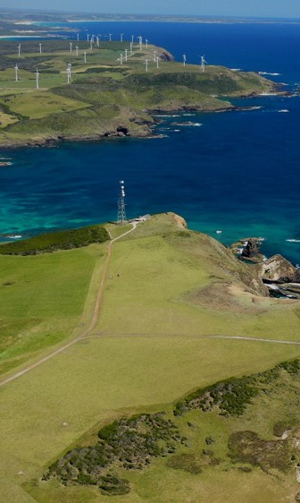

# Introduction

I am an Atmospheric Chemist who has recently joined the Major Greenhouse Gases team (GASLAB) at the Aspendale, VIC site. https://research.csiro.au/acc/capabilities/gaslab/

I started using R as part of my PhD and I was quickly hooked. Coding gives me both extreme joy and deep frustration, depending on whether my code works :) I used R throughout my postdoc and I am now keen to use my R skills in my new role.

# My Project

GASLAB maintains a suite of high-precision analytical instruments to measure the key greenhouse gases in the atmosphere. Most of the instrumentation has been in service for many years; newer, even more precise instrumentation is now available, especially for the measurement of nitrous oxide (N<sub>2</sub>O).  
Before we can implement these new methods into our operations, we need to ensure that they perform as expected and meet stringent standards for precision and accuracy. The new methods should also be free from unwanted artefacts. Once a new method is selected, we will need to seamlessly integrate the new data with the long-term (>25 years) N<sub>2</sub>O observational record.

My goal for this project was to pull together data from various instruments that measure atmospheric (N<sub>2</sub>O) to enable a comprehensive evaluation of their performance and guide our next steps in operationalising new instrumentation for use within GASLAB.

All new instrumentation is calibrated using the same suite of seven secondary standards. A number of air cylinders containing a range of ~ambient greenhouse gas concentrations are then analysed as ‘unknowns’ on each instrument. The results are compared to the assignments obtained with the long-standing operational method (SHIMADZU-1).

Three instruments are being tested as potential replacements for SHIMADZU-1:

- a GC-PDD system that measures N<sub>2</sub>O, CO<sub>2</sub>, CH<sub>4</sub> and H<sub>2</sub>
- a GC-ECD system that can measure N<sub>2</sub>O and SF<sub>6</sub>
- a Picarro G5310 system (JKADS5099) that measures N<sub>2</sub>O and CO

Although the Picarro cannot accommodate flask sample analysis, it could be useful to propagate the scale to cylinders, so is included in the analysis. The performance of these new instruments is being assessed for N<sub>2</sub>O only at present.

## Preliminary results

First, we explore the precision of the various instruments using the standard deviation of their measurements of the ‘unknown’ cylinders.

Figure 1 shows the distribution of standard deviations obtained for each instrument. The best performing is the Picarro (JKADS5099), followed by the ECD system.

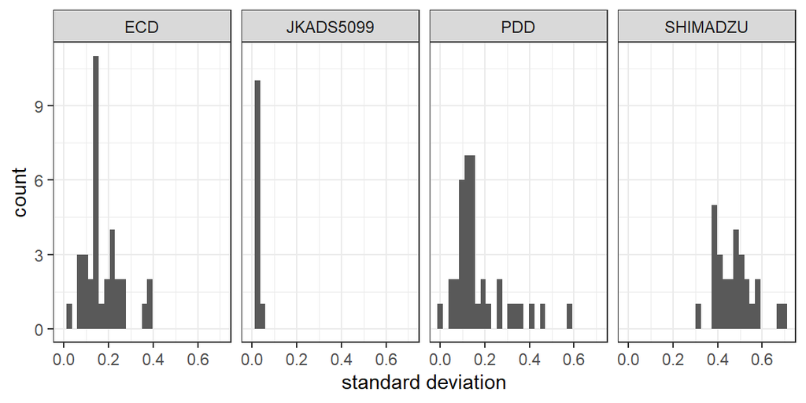

Figure 1: Distribution of instrument precision

We then explore the accuracy of the new instruments by comparing the N<sub>2</sub>O values obtained with the new instruments to those obtained with SHIMADZU-1. The convention in this field is to plot differences (instead of e.g. correlation plots).

Figure 2 shows the difference between the cylinder assignments obtained with the new instrumentation and those obtained with SHIMADZU-1. The differences are plotted against the SHIMADZU-1 N<sub>2</sub>O assignments. The plot reveals a systematic offset between the new instruments and SHIMADZU-1 at higher N<sub>2</sub>O values - this could be due to differences in calibration scheme between the new and operational instrumentation.

The main feature of Figure 2 is the large differences seen at around 325 ppm. To delve into this further, we plot the difference against the CO<sub>2</sub> content of the cylinders. Ideally, the presence or absence of CO<sub>2</sub> would not affect the N<sub>2</sub>O results. Figure 3 shows that this is not the case. Further work is under way to quantify this CO<sub>2</sub> cross-sensitivity.

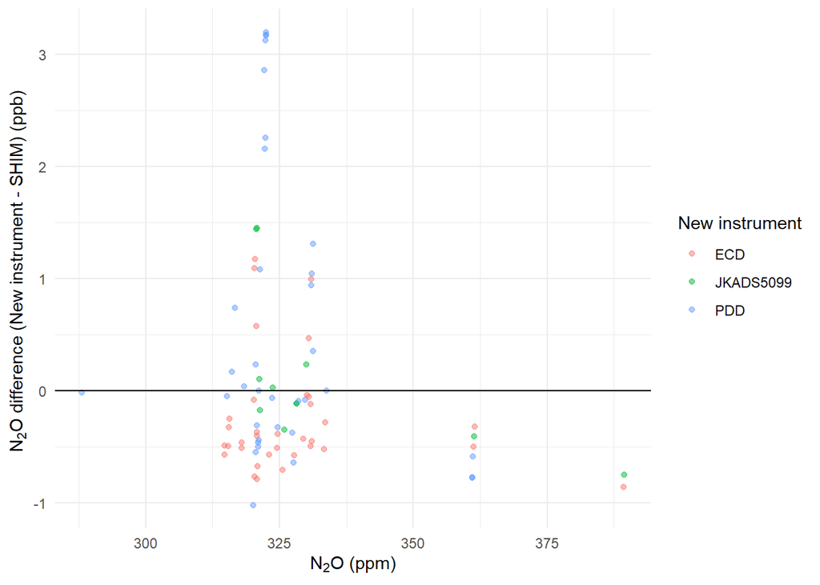

Figure 2: Summary of accuracy for N<sub>2</sub>O, plotted vs. N<sub>2</sub>O assignments

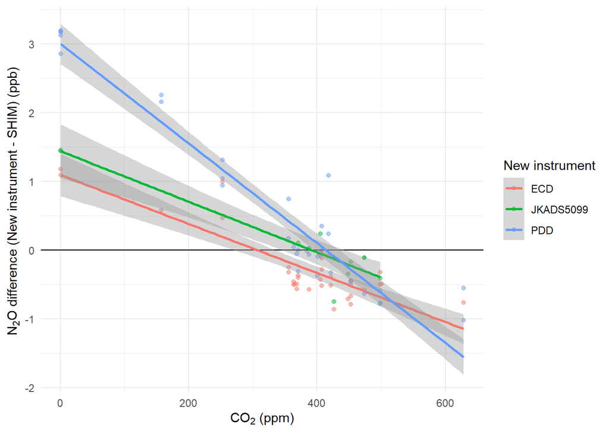

Figure 3: Summary of accuracy for N<sub>2</sub>O, plotted vs. CO<sub>2</sub> assignments

# My Digital Toolbox

I have been trying to use the packages demonstrated during Data School, to make sure some of the content sticks.

I think dplyr is very powerful and the most intuitive package I have encountered for grouping and summarising data.

Some of my favourite tools:

I actually like Rmarkdown! It’s fidly, but no worse than LateX :)

And I ♥ dbplyr (the database backend of dplyr) - it makes it so easy to ‘speak’ SQL.

# My time went …

Connecting to our database from R took a little more effort than I expected, and required the help of IM&T.  
I also spent considerable time thinking about my workflow and writing functions to try to limit code duplication across my project(s).

# Next steps

There are experimental next steps, like optimising sample delivery to the new instrumentation and widening the tests to include flask samples. There is also work to be done (both in the lab and in R) to fully characterise the CO<sub>2</sub> cross-sensitivity. There are also more involved coding tasks, such as integration of the new instrumentation into the database (yikes! luckily I don’t have to do this myself).

# My Data School Experience

Participating in Data School has given me the impetus to start using R in my CSIRO work. There is a large ‘experimental’ component to my role, and I have found it difficult to find the time to sit down and code. Aside from this poster, I have used the tools I have learned here to create a short pdf report detailing the results of tests I ran on a newly acquired instrument that was not performing up to the manufacturer’s specifications. Using Rmarkdown, it was quick and easy to put something together (so much better than copy/pasting figures in e.g. Word or inserting them in LateX) and it has enabled my manager to start a discussion with the manufacturer.

I have enjoyed all the best pratice stuff, including the data/file management material, the data workflow sessions, version control, reproducibility principles… My computer always ends up being such a mess - I am hoping to start improving the situation! These past few weeks I have been hosting a series of weekly Webex-based R workshop sessions for interested co-workers. I have been leading them so far, mostly presenting a package called ‘openair’, but I hope others will want to share their own code/knowledge/favourite packages soon (a few of them already use R).